# (Pisa 2012 Test Results Analysis)

## by (Mohammad Ayman)

## Investigation Overview

My goals are to:

1. Show The effect of OECD program for students who thought they're worthy of future careers chances all the way to those who thought they are not.
2. Showing how much a teacher's support would help in assisting students; using OECD programme policies and development assistance, compared to countries that don't have this assistance.
3. Attempting to answer a question of whether a teacher's support would be of much help for students that have a range of beliefs of maths being too hard to not at all.

## Dataset Overview

> Dataset/ Analytics were taken from PISA Survey Results, PISA is a survey of students' skills and knowledge as they approach the end of compulsory education. It is not a conventional school test. Rather than examining how well students have learned the school curriculum, it looks at how well prepared they are for life beyond school.

## (Visualization 1)

> This Visualization Shows How OECD programme helped students who had high aspirations for future career chances in assisting their ambitions and that shows in how they got higher scores than other, less ambitious students.

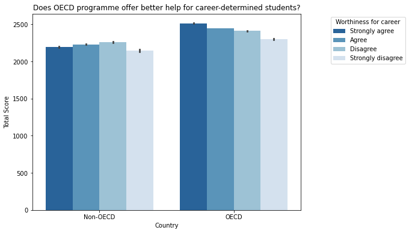

## (Visualization 2)

> Next one shows that Teacher's support would help students in countries of OECD programme, and those who aren't.

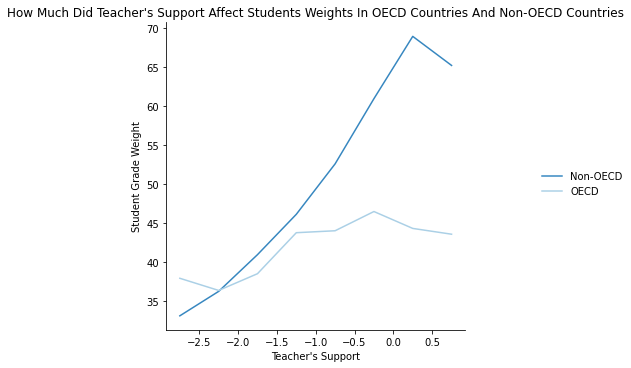

## (Visualization 3)

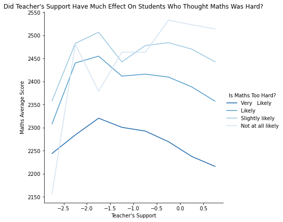

## (Visualization 4)

> How much could having disciplined climate in class affect students grades, those who see Maths as too hard, and others who don't.

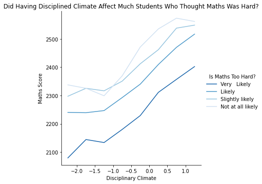